# Exercise_3_Readman_

We may want to merge some or all this data into our IPUMS data set sometime, so let’s edit the variable and label names to align:

```stata
. rename (minsamp intmonth) (mish month)

. label define MONTH 1 "january" 2 "february" 3 "march" 4 "april" 5 "may" 6 "june" ///
>                    7 "july" 8 "august" 9 "september" 10 "october" 11 "november" 12 "december"

. label values month MONTH

. label define MISH 4 "four" 8 "eight"

. label values mish MISH

. tabulate month mish

           │ Month in sample (4 &
 Interview │   8 are departing)
     month │      four      eight │     Total
───────────┼──────────────────────┼──────────
   january │    45,207     45,572 │    90,779
  february │    45,926     46,101 │    92,027
     march │    45,797     45,927 │    91,724
     april │    46,202     46,216 │    92,418
       may │    43,970     43,524 │    87,494
      june │    43,302     43,717 │    87,019
      july │    45,241     44,798 │    90,039
    august │    44,918     44,468 │    89,386
 september │    44,257     44,291 │    88,548
   october │    44,715     44,211 │    88,926
  november │    44,624     44,961 │    89,585
  december │    45,521     44,865 │    90,386
───────────┼──────────────────────┼──────────
     Total │   539,680    538,651 │ 1,078,331
```

```stata
. numlabel classer, add

. tabulate classer

                  (e&r) Class of worker │      Freq.     Percent        Cum.
────────────────────────────────────────┼───────────────────────────────────
                             1. Private │    606,926       73.61       73.61
                          2. Government │    133,281       16.16       89.77
                       3. Self-Employed │     69,780        8.46       98.23
                         4. Without Pay │      9,129        1.11       99.34
5. Never worked or never worked full-ti │      5,428        0.66      100.00
────────────────────────────────────────┼───────────────────────────────────
                                  Total │    824,544      100.00

. keep if inrange(age, 18, 64) & (classer == 1 | classer == 2)
(404,512 observations deleted)
```

```stata
. describe

Contains data
 Observations:       673,819
    Variables:            12
───────────────────────────────────────────────────────────────────────────────────────────────────────────────────────────────────────────────────────────────────────────────────────────────────────────────────
Variable      Storage   Display    Value
    name         type    format    label      Variable label
───────────────────────────────────────────────────────────────────────────────────────────────────────────────────────────────────────────────────────────────────────────────────────────────────────────────────
mish            byte    %8.0g      MISH       Month in sample (4 & 8 are departing)
month           byte    %9.0g      MONTH      Interview month
classer         byte    %41.0g     classer    (e&r) Class of worker
age             byte    %8.0g                 Age
race            byte    %8.0g      race       Race
sex             byte    %8.0g      sex        Sex
gradeat         byte    %8.0g                 Highest grade attended
esr             byte    %24.0g     esr        Employment status recode
uhours          byte    %8.0g                 (dp) Usual hours
earnwt          float   %9.0g                 (dp) Earnings weight for all races x100
earnwke         int     %8.0g                 (e&dp) Earnings per week
year            int     %8.0g
───────────────────────────────────────────────────────────────────────────────────────────────────────────────────────────────────────────────────────────────────────────────────────────────────────────────────
Sorted by:
     Note: Dataset has changed since last saved.

. summarize

    Variable │        Obs        Mean    Std. dev.       Min        Max
─────────────┼─────────────────────────────────────────────────────────
        mish │    673,819    5.995753    1.999997          4          8
       month │    673,819    6.476002    3.468601          1         12
     classer │    673,819    1.183076     .386729          1          2
         age │    673,819    36.19307    13.07602         18         64
        race │    673,819    1.155333    .4378069          1          3
─────────────┼─────────────────────────────────────────────────────────
         sex │    673,819    1.482793    .4997042          1          2
     gradeat │    673,819    12.73748    2.738672          0         18
         esr │    673,819    1.727454    1.485632          1          7
      uhours │    518,465    38.83527    10.12022         -8         99
      earnwt │    673,819     5669.77    2694.698      11.03   69937.99
─────────────┼─────────────────────────────────────────────────────────
     earnwke │    524,729    268.6182    170.3658          0        999
        year │    673,819    1980.035    .8006011       1979       1981

. summarize earnwke, detail

                  (e&dp) Earnings per week
─────────────────────────────────────────────────────────────
      Percentiles      Smallest
 1%           24              0
 5%           60              0
10%           94              0       Obs             524,729
25%          150              0       Sum of wgt.     524,729

50%          233                      Mean           268.6182
                        Largest       Std. dev.      170.3658
75%          350            999
90%          490            999       Variance       29024.51
95%          600            999       Skewness       1.448418
99%          900            999       Kurtosis       6.025732

. tab year if earnwke == .

       year │      Freq.     Percent        Cum.
────────────┼───────────────────────────────────
       1979 │     43,640       29.27       29.27
       1980 │     53,626       35.97       65.24
       1981 │     51,824       34.76      100.00
────────────┼───────────────────────────────────
      Total │    149,090      100.00
```

The mean meekly earnings is $268.62 with the median slightly lower at $233. This is interesting as I’d expect the median to be higher than the mean for earnings data, but could be easily explained by considering topcoding. Weekly earnings range from 0 to 999, which looks like a missing value code or topcode. We’ll note this and move on.

### Preparing the CPI Data

We want to analyze how real weekly wages have changed over time. We’ll need to adjust our CPS `earnweek` data for inflation using Consumer Price Index (CPI) data from the Bureau of Labor Statistics. We’ll need to get the CPI data and merge it into our cleaned CPS data.

```stata
. import excel using "../Data/SeriesReport-20250109151624_b18e88.xlsx", cellrange(A12:M124) firstrow clear
(13 vars, 112 obs)

. describe

Contains data
 Observations:           112
    Variables:            13
───────────────────────────────────────────────────────────────────────────────────────────────────────────────────────────────────────────────────────────────────────────────────────────────────────────────────
Variable      Storage   Display    Value
    name         type    format    label      Variable label
───────────────────────────────────────────────────────────────────────────────────────────────────────────────────────────────────────────────────────────────────────────────────────────────────────────────────
Year            int     %10.0g                Year
Jan             double  %10.0g                Jan
Feb             double  %10.0g                Feb
Mar             double  %10.0g                Mar
Apr             double  %10.0g                Apr
May             double  %10.0g                May
Jun             double  %10.0g                Jun
Jul             double  %10.0g                Jul
Aug             double  %10.0g                Aug
Sep             double  %10.0g                Sep
Oct             double  %10.0g                Oct
Nov             double  %10.0g                Nov
Dec             double  %10.0g                Dec
───────────────────────────────────────────────────────────────────────────────────────────────────────────────────────────────────────────────────────────────────────────────────────────────────────────────────
Sorted by:
     Note: Dataset has changed since last saved.

. summarize

    Variable │        Obs        Mean    Std. dev.       Min        Max
─────────────┼─────────────────────────────────────────────────────────
        Year │        112      1968.5    32.47563       1913       2024
         Jan │        112    87.72178     86.4136        9.8    308.417
         Feb │        112    88.05734    86.84822        9.8    310.326
         Mar │        112    88.46087    87.33292        9.8    312.332
         Apr │        112    88.79369     87.6453        9.8    313.548
─────────────┼─────────────────────────────────────────────────────────
         May │        112    89.08363    87.93985        9.7    314.069
         Jun │        112    89.39824    88.22356        9.8    314.175
         Jul │        112    89.58172    88.28814        9.9     314.54
         Aug │        112    89.76936    88.41522        9.9    314.796
         Sep │        112    90.02799     88.5862         10    315.301
─────────────┼─────────────────────────────────────────────────────────
         Oct │        112    90.17321     88.6385         10    315.664
         Nov │        112    90.16198    88.48577       10.1    315.493
         Dec │        111    88.09129    86.07916         10    306.746
```

The CPI data are for each motnh from 1913–November 2024. That is, 112 observations accross 13 variables: one for `Year` and one for each month `Jan-Dec`. In order to merge these into our CPS data, we’ll need to reshape it first to give us a `year` column a `month` column and teh `cpi` for each month of each year.

```stata
. rename Year year // rename to match CPS

. rename (Jan-Dec) m#, addnumber

. reshape long m, i(year) j(month)
(j = 1 2 3 4 5 6 7 8 9 10 11 12)

Data                               Wide   ->   Long
─────────────────────────────────────────────────────────────────────────────
Number of observations              112   ->   1,344
Number of variables                  13   ->   3
j variable (12 values)                    ->   month
xij variables:
                          m1 m2 ... m12   ->   m
─────────────────────────────────────────────────────────────────────────────

. rename m cpi

. describe

Contains data
 Observations:         1,344
    Variables:             3
───────────────────────────────────────────────────────────────────────────────────────────────────────────────────────────────────────────────────────────────────────────────────────────────────────────────────
Variable      Storage   Display    Value
    name         type    format    label      Variable label
───────────────────────────────────────────────────────────────────────────────────────────────────────────────────────────────────────────────────────────────────────────────────────────────────────────────────
year            int     %10.0g                Year
month           byte    %10.0g
cpi             double  %10.0g
───────────────────────────────────────────────────────────────────────────────────────────────────────────────────────────────────────────────────────────────────────────────────────────────────────────────────
Sorted by: year  month
     Note: Dataset has changed since last saved.
```

We should revise the labeling and formatting for ease of use:

```stata
. label variable month "Month"

. label variable cpi "Consumer Price Index"

. format cpi %9.3f
```

```stata
. sort year month

. list if year>=1982 & year<1984, noobs clean

    year   month       cpi
    1982       1    94.300
    1982       2    94.600
    1982       3    94.500
    1982       4    94.900
    1982       5    95.800
    1982       6    97.000
    1982       7    97.500
    1982       8    97.700
    1982       9    97.900
    1982      10    98.200
    1982      11    98.000
    1982      12    97.600
    1983       1    97.800
    1983       2    97.900
    1983       3    97.900
    1983       4    98.600
    1983       5    99.200
    1983       6    99.500
    1983       7    99.900
    1983       8   100.200
    1983       9   100.700
    1983      10   101.000
    1983      11   101.200
    1983      12   101.300
```

After saving, we have the following summary statistics and variables:

```stata
. summarize

    Variable │        Obs        Mean    Std. dev.       Min        Max
─────────────┼─────────────────────────────────────────────────────────
        year │      1,344      1968.5    32.34236       1913       2024
       month │      1,344         6.5    3.453337          1         12
         cpi │      1,343    89.11085    87.39035        9.7    315.664

. describe

Contains data
 Observations:         1,344
    Variables:             3
───────────────────────────────────────────────────────────────────────────────────────────────────────────────────────────────────────────────────────────────────────────────────────────────────────────────────
Variable      Storage   Display    Value
    name         type    format    label      Variable label
───────────────────────────────────────────────────────────────────────────────────────────────────────────────────────────────────────────────────────────────────────────────────────────────────────────────────
year            int     %10.0g                Year
month           byte    %10.0g                Month
cpi             double  %9.3f                 Consumer Price Index
───────────────────────────────────────────────────────────────────────────────────────────────────────────────────────────────────────────────────────────────────────────────────────────────────────────────────
Sorted by: year  month
     Note: Dataset has changed since last saved.
```

### Merging CPI and CPS-ORG Data

Let’s use our cleaned CPS 1982-2024 data from the previous session. This is our master data set into which we’ll merge the CPI data we just prepared. Let’s sort it chronologically so it aligns with the CPI data.

```stata
. use "../Data/CPS ORGs, 1982-2024, Cleaned.dta", clear

. describe

Contains data from ../Data/CPS ORGs, 1982-2024, Cleaned.dta
 Observations:     6,738,088
    Variables:            22                  11 Jan 2025 20:03
───────────────────────────────────────────────────────────────────────────────────────────────────────────────────────────────────────────────────────────────────────────────────────────────────────────────────
Variable      Storage   Display    Value
    name         type    format    label      Variable label
───────────────────────────────────────────────────────────────────────────────────────────────────────────────────────────────────────────────────────────────────────────────────────────────────────────────────
year            int     %8.0g                 survey year
month           byte    %8.0g      MONTH      month
mish            byte    %8.0g      MISH       month in sample, household level
region          byte    %8.0g      REGION     region and division
cpsidv          double  %12.0g                validated longitudinal identifier
age             byte    %8.0g      AGE        age
female          byte    %9.0g      FEMALE
race            int     %58.0g     RACE       race
empstat         byte    %8.0g      EMPSTAT    employment status
classwkr        byte    %8.0g      CLASSWKR   class of worker
uhrswork1       int     %8.0g      UHRSWORK1
                                              hours usually worked per week at main job
grade           float   %9.0g                 highest grade completed
earnwt          double  %12.0g                earnings weight
qearnwee        byte    %8.0g      QEARNWEE   data quality flag for earnweek
hourwage        double  %12.0g     HOURWAGE   hourly wage
paidhour        byte    %15.0g     PAIDHOUR   paid by the hour
union           byte    %8.0g      UNION      union membership
earnweek        double  %12.0g     EARNWEEK   weekly earnings
uhrsworkorg     byte    %8.0g                 usual hours worked per week, outgoing rotation groups
occupation      byte    %32.0g     OCCUPATION
                                              occupation (1-10)
industry        byte    %49.0g     INDUSTRY   industry (1-11)
topcode         byte    %9.0g                 topcode indicator
───────────────────────────────────────────────────────────────────────────────────────────────────────────────────────────────────────────────────────────────────────────────────────────────────────────────────
Sorted by:

. summarize

    Variable │        Obs        Mean    Std. dev.       Min        Max
─────────────┼─────────────────────────────────────────────────────────
        year │  6,738,088    2002.068    12.10799       1982       2024
       month │  6,738,088    6.505521    3.450084          1         12
        mish │  6,738,088    6.003526    1.999997          4          8
      region │  6,738,088    27.35454    10.74259         11         42
      cpsidv │  6,738,088    2.00e+14    1.21e+12   1.98e+14   2.02e+14
─────────────┼─────────────────────────────────────────────────────────
         age │  6,738,088    39.04488    12.23483         18         64
      female │  6,738,088    .4877906    .4998509          0          1
        race │  6,738,088     141.819    129.5985        100        700
     empstat │  6,738,088     10.0833    .3995664         10         12
    classwkr │  6,738,088    22.68014    2.121586         13         28
─────────────┼─────────────────────────────────────────────────────────
   uhrswork1 │  6,738,088    78.16546     189.717          0        997
       grade │  6,738,088    13.49376    2.614426          0         18
      earnwt │  6,738,088    8652.169    5093.023      90.01   209103.1
    qearnwee │  4,437,930    1.275338    1.864099          0          4
    hourwage │  3,958,207    12.89962    8.767912        .01      99.99
─────────────┼─────────────────────────────────────────────────────────
    paidhour │  6,738,088    .5876722    .4922536          0          1
       union │  6,517,337    1.172239    .4198614          1          3
    earnweek │  6,729,292    711.5078    709.6453        .01      11960
 uhrsworkorg │  2,914,349    36.77634    9.983109          1         99
  occupation │  6,738,088    3.936502     2.59726          1          9
─────────────┼─────────────────────────────────────────────────────────
    industry │  6,738,088    6.976406    2.776901          1         11
     topcode │  6,729,292    .0223624    .1478591          0          1

. sort year month
```

The data are as expected, with 6,738,088 observations over 22 variables, including weekly earnings (`earnweek`), prepared with all topcoding and missing values accounted for. We also have the earnings weight `earnwt`, which we’ll need to calculate some real wage statistics later.

Now let’s merge the CPI data into the CPS, adding a check via `assert` to make sure we’re only keeping any matched values. We don’t need CPI data for any years outside of our CPS range 1982-2024, after all.

```stata
. merge m:1 year month using "../Data/CPI 1982-2024.dta", keep(match)

    Result                      Number of obs
    ─────────────────────────────────────────
    Not matched                             0
    Matched                         6,738,088  (_merge==3)
    ─────────────────────────────────────────

. assert _merge ==3

. drop _merge //
```

Assert didn’t fail, confirming our data now has CPI data merged into it, keeping only matching values. Stata’s `_merge` variable can be dropped and we move on.

Recall that our goal is to analyze real weekly wage changes since 1982, so let’s now use the merged CPI values to compute a new real wage (`rwage`) variable.

```stata
. summarize cpi if year==$eyear & month==$emonth, meanonly

. return list

scalars:
                  r(N) =  9687
              r(sum_w) =  9687
                r(sum) =  3056180.691
               r(mean) =  315.493
                r(min) =  315.493
                r(max) =  315.493

. scalar cpi_scalar = r(mean)

. generate rwage=(cpi_scalar*earnweek)/cpi // latest month dollars
(8,796 missing values generated)

. label variable rwage "real wage in November 2024 dollars"
```

Let’s check to make sure `rwage` appears in our variables and peak at the summary statistics.

```stata
. describe

Contains data from ../Data/CPS ORGs, 1982-2024, Cleaned.dta
 Observations:     6,738,088
    Variables:            24                  11 Jan 2025 20:03
───────────────────────────────────────────────────────────────────────────────────────────────────────────────────────────────────────────────────────────────────────────────────────────────────────────────────
Variable      Storage   Display    Value
    name         type    format    label      Variable label
───────────────────────────────────────────────────────────────────────────────────────────────────────────────────────────────────────────────────────────────────────────────────────────────────────────────────
year            int     %8.0g                 survey year
month           byte    %8.0g      MONTH      month
mish            byte    %8.0g      MISH       month in sample, household level
region          byte    %8.0g      REGION     region and division
cpsidv          double  %12.0g                validated longitudinal identifier
age             byte    %8.0g      AGE        age
female          byte    %9.0g      FEMALE
race            int     %58.0g     RACE       race
empstat         byte    %8.0g      EMPSTAT    employment status
classwkr        byte    %8.0g      CLASSWKR   class of worker
uhrswork1       int     %8.0g      UHRSWORK1
                                              hours usually worked per week at main job
grade           float   %9.0g                 highest grade completed
earnwt          double  %12.0g                earnings weight
qearnwee        byte    %8.0g      QEARNWEE   data quality flag for earnweek
hourwage        double  %12.0g     HOURWAGE   hourly wage
paidhour        byte    %15.0g     PAIDHOUR   paid by the hour
union           byte    %8.0g      UNION      union membership
earnweek        double  %12.0g     EARNWEEK   weekly earnings
uhrsworkorg     byte    %8.0g                 usual hours worked per week, outgoing rotation groups
occupation      byte    %32.0g     OCCUPATION
                                              occupation (1-10)
industry        byte    %49.0g     INDUSTRY   industry (1-11)
topcode         byte    %9.0g                 topcode indicator
cpi             double  %9.3f                 Consumer Price Index
rwage           float   %9.0g                 real wage in November 2024 dollars
───────────────────────────────────────────────────────────────────────────────────────────────────────────────────────────────────────────────────────────────────────────────────────────────────────────────────
Sorted by:
     Note: Dataset has changed since last saved.
```

```stata
. summarize

    Variable │        Obs        Mean    Std. dev.       Min        Max
─────────────┼─────────────────────────────────────────────────────────
        year │  6,738,088    2002.068    12.10799       1982       2024
       month │  6,738,088    6.505521    3.450084          1         12
        mish │  6,738,088    6.003526    1.999997          4          8
      region │  6,738,088    27.35454    10.74259         11         42
      cpsidv │  6,738,088    2.00e+14    1.21e+12   1.98e+14   2.02e+14
─────────────┼─────────────────────────────────────────────────────────
         age │  6,738,088    39.04488    12.23483         18         64
      female │  6,738,088    .4877906    .4998509          0          1
        race │  6,738,088     141.819    129.5985        100        700
     empstat │  6,738,088     10.0833    .3995664         10         12
    classwkr │  6,738,088    22.68014    2.121586         13         28
─────────────┼─────────────────────────────────────────────────────────
   uhrswork1 │  6,738,088    78.16546     189.717          0        997
       grade │  6,738,088    13.49376    2.614426          0         18
      earnwt │  6,738,088    8652.169    5093.023      90.01   209103.1
    qearnwee │  4,437,930    1.275338    1.864099          0          4
    hourwage │  3,958,207    12.89962    8.767912        .01      99.99
─────────────┼─────────────────────────────────────────────────────────
    paidhour │  6,738,088    .5876722    .4922536          0          1
       union │  6,517,337    1.172239    .4198614          1          3
    earnweek │  6,729,292    711.5078    709.6453        .01      11960
 uhrsworkorg │  2,914,349    36.77634    9.983109          1         99
  occupation │  6,738,088    3.936502     2.59726          1          9
─────────────┼─────────────────────────────────────────────────────────
    industry │  6,738,088    6.976406    2.776901          1         11
     topcode │  6,729,292    .0223624    .1478591          0          1
         cpi │  6,738,088    184.1752    56.16483       94.3    315.664
       rwage │  6,729,292    1187.022    992.6475   .0104871   11986.48
```

### Annual Summary Statistics and Visualization

```stata
. collapse (mean) mean=rwage /// mean
>               (p10) p10=rwage /// 10th percentile
>               (p50) p50=rwage /// 10th percentile
>               (p90) p90=rwage /// 90th percentile
>               [pw=earnwt], by(year)

. generate ldiff=100*(ln(p90) - ln(p10))

. format ldiff %4.1f
```

```stata
. describe

Contains data
 Observations:            43
    Variables:             6
───────────────────────────────────────────────────────────────────────────────────────────────────────────────────────────────────────────────────────────────────────────────────────────────────────────────────
Variable      Storage   Display    Value
    name         type    format    label      Variable label
───────────────────────────────────────────────────────────────────────────────────────────────────────────────────────────────────────────────────────────────────────────────────────────────────────────────────
year            int     %8.0g                 survey year
mean            float   %9.0g                 (mean) rwage
p10             float   %9.0g                 (p 10) rwage
p50             float   %9.0g                 (p 50) rwage
p90             float   %9.0g                 (p 90) rwage
ldiff           float   %4.1f
───────────────────────────────────────────────────────────────────────────────────────────────────────────────────────────────────────────────────────────────────────────────────────────────────────────────────
Sorted by: year
     Note: Dataset has changed since last saved.

. summarize

    Variable │        Obs        Mean    Std. dev.       Min        Max
─────────────┼─────────────────────────────────────────────────────────
        year │         43        2003    12.55654       1982       2024
        mean │         43    1193.283    114.1745   1029.591   1477.799
         p10 │         43    352.1819    30.09094   315.8152   423.4635
         p50 │         43    935.8289    53.61567   863.1819   1071.522
         p90 │         43    2241.837      255.01   1828.463   2749.459
─────────────┼─────────────────────────────────────────────────────────
       ldiff │         43    184.7998    7.395999   173.1777   199.8685

. list in 1/5, noobs

  ┌──────────────────────────────────────────────────────────┐
  │ year       mean        p10        p50        p90   ldiff │
  ├──────────────────────────────────────────────────────────┤
  │ 1982   1029.591   323.5826   867.1055   1828.463   173.2 │
  │ 1983   1041.954   315.8152    874.634   1874.216   178.1 │
  │ 1984   1055.879   318.2206   897.8702   1857.662   176.4 │
  │ 1985   1069.052     322.53   882.0867   1916.957   178.2 │
  │ 1986   1096.014   333.1653   898.9231   2000.409   179.2 │
  └──────────────────────────────────────────────────────────┘
```

Figure 1 shows trends in wage percentiles (10th, 50th, 90th, and mean) from 1982 to 2024, highlighting disparities in wage growth across income levels. The widening gap between the 90th and 10th percentiles indicates increasing wage inequality over the period.

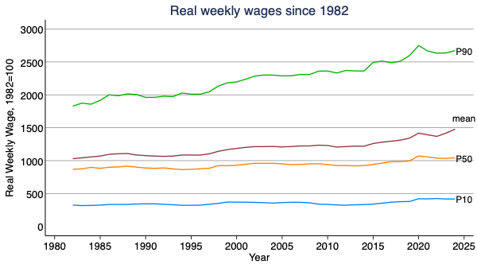

Real Weekly Wage Percentiles, 1982–2924

Figure 2 illustrates the log differences between the 90th and 10th percentiles of real weekly wages from 1982 to 2024. It captures changes in wage inequality over time, showing fluctuations followed by a steep incline, peaking around 2010–2015. Since then, there’s a stinking decline in real wage inequality.

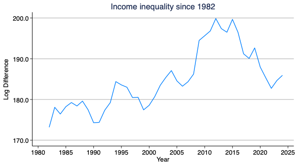